# Sesión 7

# ESTADISTICA PARA EL ANALISIS POLITICO II

- Profesor: [Dr. José Manuel Magallanes, Ph.D.](http://www.pucp.edu.pe/profesor/jose-manuel-magallanes/)
  - Profesor del Departamento de Ciencias Sociales, Sección de Ciencia Política y Gobierno.
  - [Oficina 105](https://goo.gl/maps/xuGeG6o9di1i1y5m6) - Edificio CISEPA / ECONOMIA / CCSS
  - Telefono: (51) 1 - 6262000 anexo 4302
  - Correo Electrónico: jmagallanes@pucp.edu.pe

## Análisis de Variables Latentes

Muchas veces queremos saber si las algun conjunto de variables representa algun *concepto*, al cual se le denomina técnicamente *variable latente*. Las técnicas son variadas, pero aquí aplicaremos análisis factorial, el exploratorio y el confirmatorio para tratar de *reducir* varias variables en otra u otras más simples.

# Análisis Factorial Exploratorio (*EFA*)

## Preparación de Datos:

Para esta sesión trabajaremos con la data de estos links:

- https://en.wikipedia.org/wiki/Democracy_Index

```r
library(htmltab)

demoL=c("https://en.wikipedia.org/wiki/Democracy_Index",
        '//*[@id="mw-content-text"]/div[1]/table[10]')

demo  = htmltab(doc = demoL[1], which  = demoL[2], encoding = "UTF-8")

# limpieza
demo[,]=lapply(demo[,], trimws,whitespace = "[\\h\\v]") # no blanks

library(stringr) # nombres simples
names(demo)=str_split(names(demo),">>",simplify = T)[,1]
names(demo)=trimws(names(demo),whitespace = "[\\h\\v]")

## Formateo
#guion invisible
names(demo)=gsub('\u00AD','',names(demo))
#capitalizar
names(demo)=str_to_title(names(demo))
#espacios por "."
names(demo)=names(demo)=gsub('\\s','_',names(demo))

# Eliminemos columnas que no usaremos:
demo[,c(1,2,11)]=NULL

# Tipo de variables:

## En demo:
# a numerica
demo[,-c(1,2)]=lapply(demo[,-c(1,2)],as.numeric)

# a ordinal
regimeLevels=c("Authoritarian","Hybrid regime","Flawed democracy","Full democracy")
demo$Regime_Type=factor(demo$Regime_Type,
                   levels=regimeLevels,
                   ordered = T)
# sin perdidos:
demo=na.omit(demo)
```

## Proceso del Analisis Factorial Exploratorio (EFA)

El análisis factorial exploratorio requiere que hagamos algunas observaciones previas.

1. Calculemos matriz de correlación:

```r
dontselect=c("Country","Regime_Type","Overall_Score")
select=setdiff(names(demo),dontselect)
theData=demo[,select] # sin los Scores ni nombre de país.


# esta es:
library(polycor)
corMatrix=polycor::hetcor(theData)$correlations
```

2. Explorar correlaciones:
- Sin evaluar significancia:

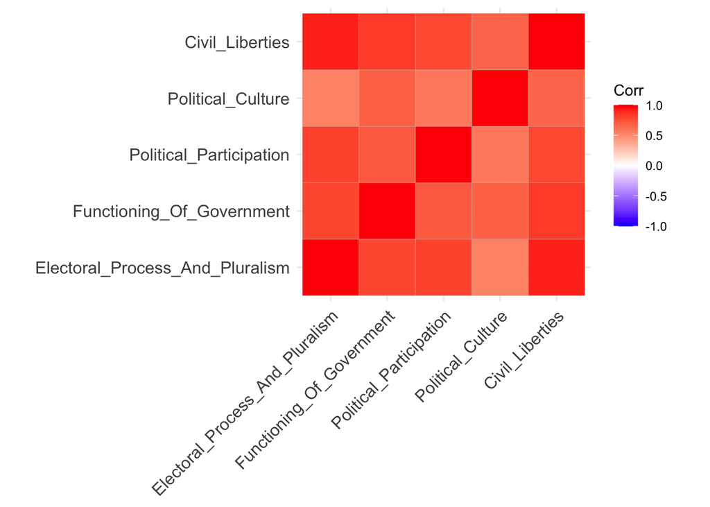

```r
library(ggcorrplot)

ggcorrplot(corMatrix)
```

Si puedes ver bloques correlacionados, hay esperanza de un buen analisis factorial.

3. Verificar si datos permiten factorizar:

```r
library(psych)
psych::KMO(corMatrix)
```

```
## Kaiser-Meyer-Olkin factor adequacy
## Call: psych::KMO(r = corMatrix)
## Overall MSA =  0.83
## MSA for each item =
## Electoral_Process_And_Pluralism       Functioning_Of_Government
##                            0.76                            0.92
##         Political_Participation               Political_Culture
##                            0.92                            0.81
##                 Civil_Liberties
##                            0.79
```

4. Verificar si la matriz de correlaciones es adecuada

Aqui hay dos pruebas:

- Hnula: La matriz de correlacion es una [matriz identidad](https://en.wikipedia.org/wiki/Identity_matrix)

```r
cortest.bartlett(corMatrix,n=nrow(theData))$p.value>0.05
```

```
## [1] FALSE
```

- Hnula: La matriz de correlacion es una [matriz singular](http://mathworld.wolfram.com/SingularMatrix.html).

```r
library(matrixcalc)

is.singular.matrix(corMatrix)
```

```
## [1] FALSE
```

5. Determinar en cuantos factores o variables latentes podríamos redimensionar la data:

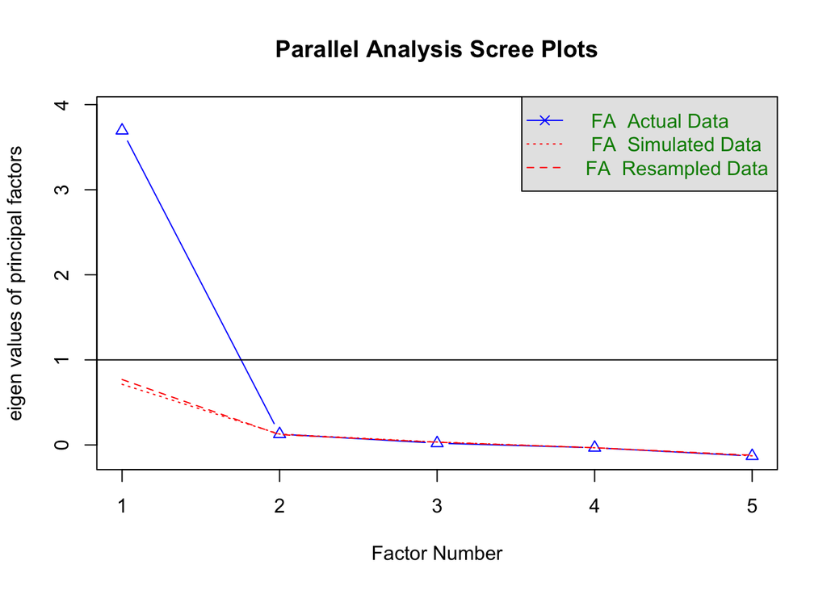

```
## Parallel analysis suggests that the number of factors =  1  and the number of components =  NA
```

```r
fa.parallel(theData,fm = 'ML', fa = 'fa',correct = T)
```

Se sugiere 1, lo esperado, sigamos.

6. Redimensionar a numero menor de factores
- Resultado inicial:

```r
library(GPArotation)
resfa <- fa(theData,
            nfactors = 1,
            cor = 'mixed',
            rotate = "varimax",
            fm="minres")
print(resfa$loadings)
```

```
##
## Loadings:
##                                 MR1
## Electoral_Process_And_Pluralism 0.907
## Functioning_Of_Government       0.883
## Political_Participation         0.830
## Political_Culture               0.688
## Civil_Liberties                 0.966
##
##                  MR1
## SS loadings    3.696
## Proportion Var 0.739
```

- Resultado mejorado (solo apropiado si hay más de un factor):

```r
print(resfa$loadings,cutoff = 0.5)
```

```
##
## Loadings:
##                                 MR1
## Electoral_Process_And_Pluralism 0.907
## Functioning_Of_Government       0.883
## Political_Participation         0.830
## Political_Culture               0.688
## Civil_Liberties                 0.966
##
##                  MR1
## SS loadings    3.696
## Proportion Var 0.739
```

Cuando logramos que cada variable se vaya a un factor, tenemos una *estructura simple*.

- Resultado visual:

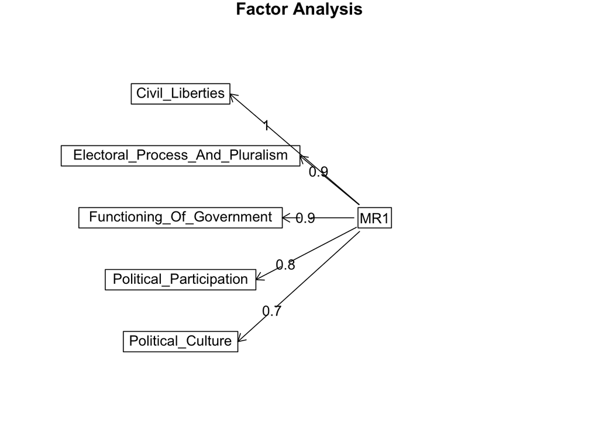

```r
fa.diagram(resfa)
```

7. Evaluando Resultado obtenido:
- ¿Qué variables aportaron mas a los factores?

```r
sort(resfa$communality)
```

```
##               Political_Culture         Political_Participation
##                       0.4727270                       0.6889009
##       Functioning_Of_Government Electoral_Process_And_Pluralism
##                       0.7794345                       0.8231486
##                 Civil_Liberties
##                       0.9321980
```

- ¿Qué variables contribuyen a mas de un factor?

```r
sort(resfa$complexity)
```

```
## Electoral_Process_And_Pluralism       Functioning_Of_Government
##                               1                               1
##         Political_Participation               Political_Culture
##                               1                               1
##                 Civil_Liberties
##                               1
```

8. Posibles valores proyectados:

¿Qué nombres les darías?

```r
as.data.frame(resfa$scores)%>%head()
```

```
##        MR1
## 3 1.784667
## 4 1.607728
## 5 1.550239
## 6 1.692963
## 7 1.623809
## 8 1.625215
```

El nombre sería democracia. Y debe estar correlacionado con el puntaje propuesto por TheEconomist:

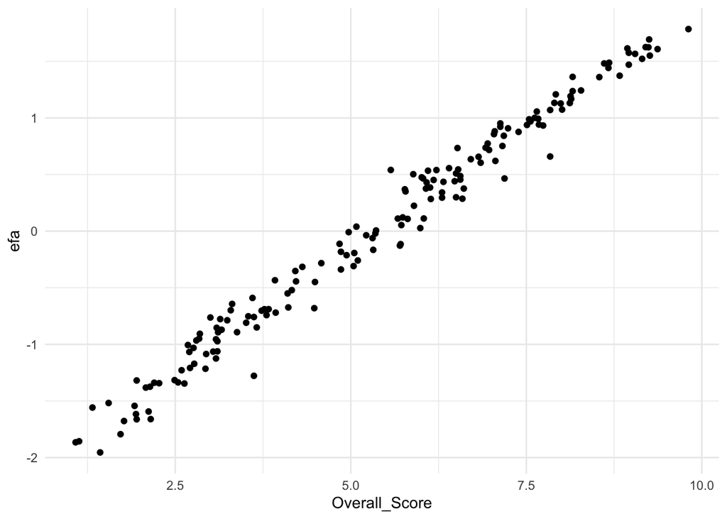

```r
demo$efa=resfa$scores

ggplot(data=demo,aes(x=Overall_Score,y=efa)) + geom_point() + theme_minimal()
```

Nota que los valores no son parecidos. Pero podríamos cambiar el rango:

```r
library(BBmisc)
demo$efa_ok=normalize(demo$efa,
                       method = "range",
                       margin=2, # by column
                       range = c(0, 10))
```

Esto te daría:

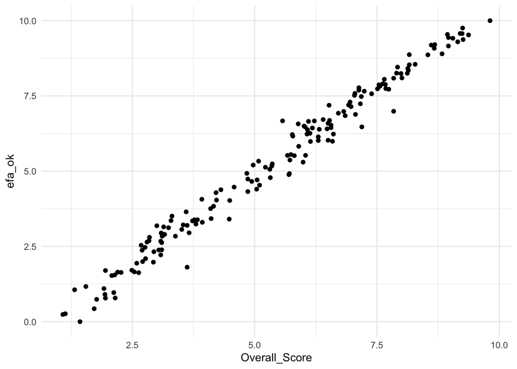

```r
ggplot(data=demo,aes(x=Overall_Score,y=efa_ok)) + geom_point() + theme_minimal()
```

El problema sería que en la nueva variable aparecen casos 0 y casos 10. Es decir la data debe ser modificada:

```r
# creo 5 valores con 10
top=rep(10,5)
# creo 5 valores con 0
bottom=rep(0,5)
# hago data frame con eso:
limitCases=as.data.frame(rbind(bottom,top))

# vuelvo a subsetear
theData=demo[,select]
names(limitCases)=names(theData)
#anexo
theData=rbind(theData,limitCases)

# nuevamente
resfa <- fa(theData,
            nfactors = 1,
            cor = 'mixed',
            rotate = "varimax",
            fm="minres")

scores=normalize(resfa$scores,
                 method = "range",
                 margin=2, # by column
                 range = c(0, 10))
#tenemos:
tail(scores)
```

```
##               MR1
## 169     0.6508041
## 170     1.5845483
## 171     0.8850546
## 172     0.8748605
## bottom  0.0000000
## top    10.0000000
```

De ahi que:

```r
demo$efa_ok=head(scores,-2)
```

Ahora sí:

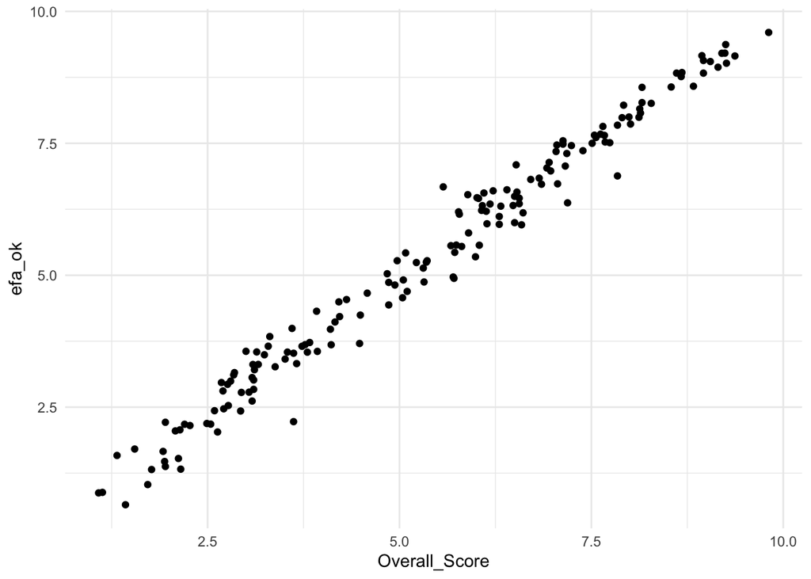

```r
ggplot(data=demo,aes(x=Overall_Score,y=efa_ok)) + geom_point() + theme_minimal()
```

# ANALISIS FACTORIAL CONFIRMATORIO

Si la exploración apoyaba nuestro marco teórico, podemos proponer cómo construir los indices:

```r
model <- ' democracia  =~ Electoral_Process_And_Pluralism + Functioning_Of_Government + Political_Participation + Political_Culture + Civil_Liberties'
```

Ahora vemos qué arroja el modelo:

```r
# normalizar las variables:
theDataNorm=scale(theData)

library(lavaan)
cfa_fit <- cfa(model, data=theDataNorm,
           std.lv=TRUE,
           missing="fiml")
```

Preparo los tests:

```r
allParamCFA=parameterEstimates(cfa_fit,standardized = T)
allFitCFA=as.list(fitMeasures(cfa_fit))
```

Veamos resultados:

- Si cada indicador tiene una buena conexión con su latente (ver p valor):

```r
allParamCFA[allParamCFA$op=="=~",]
```

```
##          lhs op                             rhs   est    se      z pvalue
## 1 democracia =~ Electoral_Process_And_Pluralism 0.926 0.058 15.900      0
## 2 democracia =~       Functioning_Of_Government 0.866 0.061 14.166      0
## 3 democracia =~         Political_Participation 0.824 0.063 13.055      0
## 4 democracia =~               Political_Culture 0.695 0.068 10.282      0
## 5 democracia =~                 Civil_Liberties 0.969 0.056 17.258      0
##   ci.lower ci.upper std.lv std.all std.nox
## 1    0.812    1.040  0.926   0.929   0.929
## 2    0.746    0.985  0.866   0.868   0.868
## 3    0.700    0.948  0.824   0.826   0.826
## 4    0.563    0.828  0.695   0.698   0.698
## 5    0.859    1.080  0.969   0.972   0.972
```

Averigüemos qué tan bien salió el modelo:

- El ChiSquare es NO significativo? (p_value debe ser mayor a 0.05 para que sea bueno)

```r
allFitCFA[c("chisq", "df", "pvalue")] # pvalue>0.05
```

```
## $chisq
## [1] 47.38206
##
## $df
## [1] 5
##
## $pvalue
## [1] 4.748453e-09
```

- El Índice Tucker Lewi es mayor a 0.9?

```r
allFitCFA$tli # > 0.90
```

```
## [1] 0.8977617
```

- La Raíz del error cuadrático medio de aproximación es menor a 0.05?

```r
allFitCFA[c('rmsea.ci.lower','rmsea' ,'rmsea.ci.upper')] # 0.05 en el Int de Conf?
```

```
## $rmsea.ci.lower
## [1] 0.16837
##
## $rmsea
## [1] 0.223956
##
## $rmsea.ci.upper
## [1] 0.2842437
```

Ya sabemos que no hay buen augurio.

```r
scorescfa=normalize(lavPredict(cfa_fit),
                    method = "range",
                    margin=2, # by column
                    range = c(0, 10))
```

De ahi que:

```r
demo$cfa_ok=head(scorescfa,-2)
```

Veamos ambos scores calculados

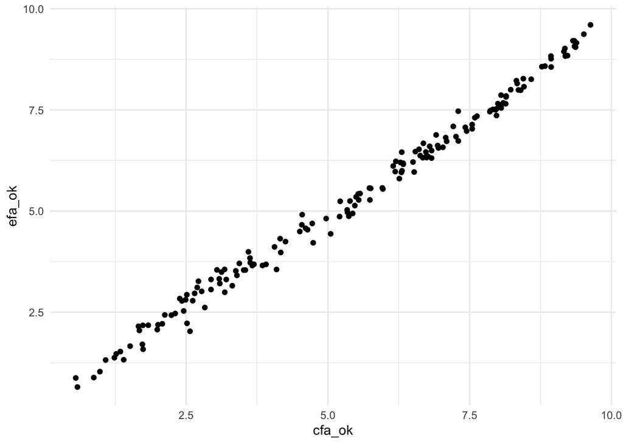

```r
ggplot(data=demo,aes(x=cfa_ok,y=efa_ok)) + geom_point() + theme_minimal()
```

- **EJERCICIO**
1. Añada otro concepto latente que use varias variables. Siga todos los pasos anteriores.
2. Plantee una regresión Gaussiana, con una “Y” que se una variable latente (varias variables), y dos “X”s que también sean latentes (varias variables por cada “X”). Use las latentes teorizadas (sus ‘scores’) para la regresión.